# Hypothesis tests & probability - weekend homework

Jerry Balloch

```r
library(tidyverse)
```

# Question 1.

Explore the dataset and familiarise yourself with it.

```r
dim(msleep)
```

```
[1] 83 11
```

```r
names(msleep)
```

```
 [1] "name"         "genus"        "vore"         "order"        "conservation" "sleep_total"
 [7] "sleep_rem"    "sleep_cycle"  "awake"        "brainwt"      "bodywt"
```

```r
glimpse(msleep)
```

```
Rows: 83
Columns: 11
$ name         <chr> "Cheetah", "Owl monkey", "Mountain beaver", "Greater short-tailed shrew", …
$ genus        <chr> "Acinonyx", "Aotus", "Aplodontia", "Blarina", "Bos", "Bradypus", "Callorhi…
$ vore         <chr> "carni", "omni", "herbi", "omni", "herbi", "herbi", "carni", NA, "carni", …
$ order        <chr> "Carnivora", "Primates", "Rodentia", "Soricomorpha", "Artiodactyla", "Pilo…
$ conservation <chr> "lc", NA, "nt", "lc", "domesticated", NA, "vu", NA, "domesticated", "lc", …
$ sleep_total  <dbl> 12.1, 17.0, 14.4, 14.9, 4.0, 14.4, 8.7, 7.0, 10.1, 3.0, 5.3, 9.4, 10.0, 12…
$ sleep_rem    <dbl> NA, 1.8, 2.4, 2.3, 0.7, 2.2, 1.4, NA, 2.9, NA, 0.6, 0.8, 0.7, 1.5, 2.2, 2.…
$ sleep_cycle  <dbl> NA, NA, NA, 0.1333333, 0.6666667, 0.7666667, 0.3833333, NA, 0.3333333, NA,…
$ awake        <dbl> 11.90, 7.00, 9.60, 9.10, 20.00, 9.60, 15.30, 17.00, 13.90, 21.00, 18.70, 1…
$ brainwt      <dbl> NA, 0.01550, NA, 0.00029, 0.42300, NA, NA, NA, 0.07000, 0.09820, 0.11500, …
$ bodywt       <dbl> 50.000, 0.480, 1.350, 0.019, 600.000, 3.850, 20.490, 0.045, 14.000, 14.800…
```

# Question 2.

Jabberwockies sleep for around 7 hours a night, on average. Perform an appropriate statistical test to determine whether the mean sleep_total in the sampled population of animal types differs from the typical value for jabberwockies.

**Answer:** The mean of sleep_total is 11.22 hours. Jaberwockies sleep an average 7 hours a night, so less than the over all average of the animals in our sample.

| mean_sleep_total |
| --- |
| 11.225 |

# Question 3.

Perform an appropriate statistical test to determine whether omnivores sleep for significantly longer than herbivores, on average.

**Answer:**

**α = 0.05**  
**H0 : There is no difference in average sleep totals between omnivores and herbivores.**  
**Ha : The mean of sleep totals of omnivores is significantly longer than the mean of herbivores sleep totals.**

```r
# calculating the total means of sleep by vore
msleep %>%
  group_by(vore) %>%
  filter(vore %in% c("omni", "herbi")) %>%
  na.omit(sleep_total, vore) %>%
  summarise(mean_sleep_total = mean(sleep_total))
```

| vore | mean_sleep_total |
| --- | --- |
| herbi | 9.52 |
| omni | 12.24 |

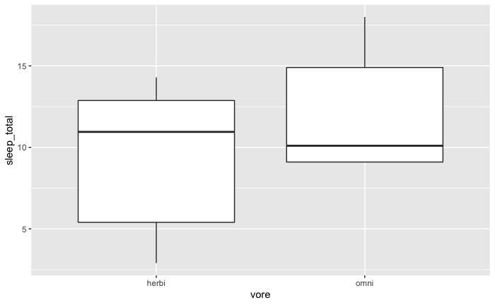

```r
# create a dataset with just omni and herbi vores, removing any NA values
omni_herbi <- msleep %>%
  group_by(vore) %>%
  filter(vore %in% c("omni", "herbi")) %>%
  na.omit(sleep_total, vore)

# visualise the data using a boxplot
omni_herbi %>%
  ggplot(aes(x = vore, y = sleep_total)) +
  geom_boxplot()
```

```r
# create a null distribution
null_distribution <- omni_herbi %>%
  specify(sleep_total ~ vore) %>%
  hypothesize(null = "independence") %>%
  generate(reps = 10000, type = "permute") %>%
  calculate(stat = "diff in means", order = c("omni", "herbi"))

# calculate observed statistic
observed_stat <- omni_herbi %>%
  specify(sleep_total ~ vore) %>%
  calculate(stat = "diff in means", order = c("omni", "herbi"))

observed_stat
```

```
Response: sleep_total (numeric)
Explanatory: vore (factor)
```

| stat |
| --- |
| 2.72 |

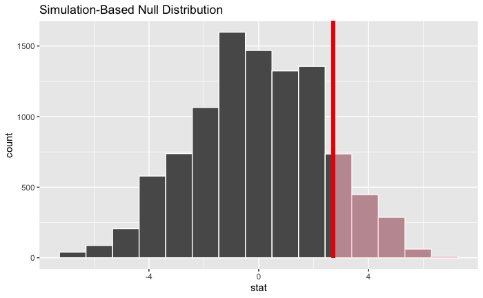

```r
# visualise the observed stat on the distribution
null_distribution %>%
  visualise() +
  shade_p_value(obs_stat = observed_stat, direction = "right")
```

```r
# get the p=value
p_value <- null_distribution %>%
  get_p_value(obs_stat = observed_stat, direction = "right")

p_value
```

| p_value |
| --- |
| 0.1367 |

```r
NA
NA
```

# Question 4.

Perform an appropriate statistical test to determine whether the proportion of domesticated animal types in the population of animal types is greater than 5%.

**Answer:** I have worked out that domesticated animals make up 12.05% of the total count of all the animals so is greater than 5%, but I couldn’t work out how to do it based on distributions. Couldn’t work out how to split the column properly.

```r
10 / 83 * 100
```

```
[1] 12.04819
```

# 1.2 Hypothesis testing - Defining the Hypothesis

For the following three business problems write out:

- What kind of test you would use
- H0 and Ha in both mathematical notation and in words
- Also state the method you would use to generate the null distribution (bootstrap, permutation or simulation).

### Question 1.

You work for a independent coffee shop. The boss tells you that she thinks that around 40% of people in the town (population 30,000) know of the coffee shop, but you are skeptical of the estimate. You conduct a random survey of 200 people in the town, asking if respondents are aware of your coffee shop. You want to use the sample to test the hypothesis that 40% or more of the town’s population have heard of the coffee shop.

**Answer:**

I would use a One-Sample Proportion Test in this case.

$$H0: π0=a$$

$$Ha: π0<a$$
$$Statistic: p = 0.40$$
**H0 : The proportion of people that have heard of the coffee shop is 40%**
**Ha : The proportion of people that have heard of the coffee shop is less than 40%**

The null distribution does not rely on our sample data. To create it I would use the `simulate method` using, `point` function in `hypothesise` with a `p = 0.40`, and generate 1000 reps using the `draw` function to simulate the number of people having heard of the coffee shop.

### Question 2.

You work for a website design company and have performed an A/B test on the position of a banner on a website promoting a particular item.

You selected five days at random last month and then randomly selected 200 of each sampled day’s users into group A and another 200 of that day’s users into group B. Group A continued to be shown the banner at the right hand side of the webpage (its usual position) while group B was shown the banner at the top of the page. You monitored each sampled user’s interactions with the website, in particular the ‘click through rate’ (CTR) on the banner, i.e. what proportion of sampled users clicked on the banner. You want to use the sampled data to test the hypothesis that website users overall are more likely to click on the banner if positioned at the top of the page.

**Answer:**

I would use a Two-means Paired Sample Test in this case.

$$H0:μdiff=0$$

$$Ha: μdiff>0$$
**H0 : The proportion of people that clicked the banner didn’t differ on position of banner**
**Ha : There was a higher proportion of people that clicked the banner when it was at the top**

For the null distribution I would create a new variable that is the difference of the two paired responses and bootstrap based on the difference variable.

### Question 3.

You work as an analyst for a car manufacturing company - they have specific standards they must meet for standards and regulation purposes. You have been asked to check the quality control of the manufacture of a particular car part. You have been given data on a sample of 200 parts produced over the period of a week (the sampled parts were pulled at random from the production line and measured: the factory produced a lot more than 200 parts that week). The specification of the part stipulates a width of 145mm, and the manufacturing process is said to have ‘drifted’ if the mean width of parts differs significantly from 145mm. You want to use the sampled measurements to test whether the process overall has drifted.

**Answer:**

I would use a One-sample mean Test in this case.

$$H0:μ0=a$$
$$H0:μ0≠a$$
**H0 : The mean width of car part pulled was equal to 145mm**
**Ha : The mean width of car part pulled was not equal to 145mm**

I would `bootstrap` from our given sample to generate the null distribution.

# 1.3 Hypothesis Testing - Interpreting the results

For the 3 business problems stated above, imagine we performed you got the following p-values (with the given significance levels) write out your interpretation of the results.

### Question 1.

Coffee shop problem. Significance level: 0.05, calculated p-value: 0.07

**Answer:** We fail to reject the null hypothesis here as the p-value is greater than `a`.

### Question 2.

Website company problem. Significance level: 0.01, p-value: 0.006

**Answer:** We reject the null hypothesis here as the p-value is less than `a`.

### Question 3.

Manufacturing company problem. Significance level: 0.05, p-value: 0.55